# 16 Shape analysis and comparison

> “The book of nature is written in the language of mathematics.”  
> — Galileo Galilei

How can we tell if two shapes are “similar”? Traditional approaches rely on specific geometric measurements — lengths, angles, volumes — which depend on the coordinate system and are sensitive to noise. Persistent homology offers a coordinate-free, noise-robust alternative: compare shapes by comparing their persistence diagrams.

In this chapter, we use Wasserstein distances between persistence diagrams to build a simple “shape space” — a metric space where each point is a shape, and the distance reflects topological similarity. The point is not to compare raw coordinates directly, but to compare the topological signatures extracted from the data.

## 16.1 Setup

```julia
using CairoMakie
using MetricSpaces
using MetricSpaces.Datasets
using PersistenceDiagrams
using Ripserer
using Random
```

## 16.2 Generating a shape library

Let’s create a collection of point clouds from shapes with known topology:

```julia
function sample_shape(shape, n, seed)
    rng = MersenneTwister(seed)
    noise_level = 0.05

    if shape == :circle
        return EuclideanSpace(as_matrix(sphere(n, dim = 2)) .+ noise_level .* randn(rng, 2, n))
    elseif shape == :sphere
        return EuclideanSpace(as_matrix(sphere(n, dim = 3)) .+ noise_level .* randn(rng, 3, n))
    elseif shape == :torus
        return EuclideanSpace(as_matrix(torus(n)) .+ noise_level .* randn(rng, 3, n))
    elseif shape == :two_circles
        c1 = as_matrix(sphere(n ÷ 2, dim = 2))
        c2 = as_matrix(sphere(n ÷ 2, dim = 2)) .+ [3.0, 0.0]
        return EuclideanSpace(hcat(c1, c2) .+ noise_level .* randn(rng, 2, n))
    elseif shape == :blob
        return EuclideanSpace(0.5 .* randn(rng, 3, n))
    else
        error("Unknown shape: $shape")
    end
end
```

```
sample_shape (generic function with 1 method)
```

```julia
shapes = [
    :circle, :circle, :circle,
    :sphere, :sphere, :sphere,
    :torus, :torus, :torus,
    :two_circles, :two_circles, :two_circles,
    :blob, :blob, :blob,
]

n_points = 100
clouds = [sample_shape(s, n_points, i) for (i, s) in enumerate(shapes)]
shape_names = string.(shapes)
```

```
15-element Vector{String}:
 "circle"
 "circle"
 "circle"
 "sphere"
 "sphere"
 "sphere"
 "torus"
 "torus"
 "torus"
 "two_circles"
 "two_circles"
 "two_circles"
 "blob"
 "blob"
 "blob"
```

## 16.3 Computing persistence diagrams for each shape

```julia
function compute_ph(X; dim_max = 1, threshold = 3.0)
    ripserer(Rips(X; threshold = threshold), dim_max = dim_max)
end

diagrams = [compute_ph(X) for X in clouds]
```

```
15-element Vector{Vector{PersistenceDiagram}}:
 [100-element 0-dimensional PersistenceDiagram, 2-element 1-dimensional PersistenceDiagram]
 [100-element 0-dimensional PersistenceDiagram, 4-element 1-dimensional PersistenceDiagram]
 [100-element 0-dimensional PersistenceDiagram, 5-element 1-dimensional PersistenceDiagram]
 [100-element 0-dimensional PersistenceDiagram, 26-element 1-dimensional PersistenceDiagram]
 [100-element 0-dimensional PersistenceDiagram, 27-element 1-dimensional PersistenceDiagram]
 [100-element 0-dimensional PersistenceDiagram, 19-element 1-dimensional PersistenceDiagram]
 [100-element 0-dimensional PersistenceDiagram, 23-element 1-dimensional PersistenceDiagram]
 [100-element 0-dimensional PersistenceDiagram, 24-element 1-dimensional PersistenceDiagram]
 [100-element 0-dimensional PersistenceDiagram, 31-element 1-dimensional PersistenceDiagram]
 [100-element 0-dimensional PersistenceDiagram, 2-element 1-dimensional PersistenceDiagram]
 [100-element 0-dimensional PersistenceDiagram, 5-element 1-dimensional PersistenceDiagram]
 [100-element 0-dimensional PersistenceDiagram, 6-element 1-dimensional PersistenceDiagram]
 [100-element 0-dimensional PersistenceDiagram, 31-element 1-dimensional PersistenceDiagram]
 [100-element 0-dimensional PersistenceDiagram, 26-element 1-dimensional PersistenceDiagram]
 [100-element 0-dimensional PersistenceDiagram, 32-element 1-dimensional PersistenceDiagram]
```

## 16.4 Building a distance matrix

Now we compare every pair of shapes using the Wasserstein distance on their $H_1$ persistence diagrams:

```julia
n_shapes = length(diagrams)
dist_matrix = zeros(n_shapes, n_shapes)

for i in 1:n_shapes
    for j in (i + 1):n_shapes
        d1 = diagrams[i][2]
        d2 = diagrams[j][2]

        if !isempty(d1) && !isempty(d2)
            d = Wasserstein()(d1, d2)
            dist_matrix[i, j] = isfinite(d) ? d : 1.0
        elseif isempty(d1) && isempty(d2)
            dist_matrix[i, j] = 0.0
        else
            dist_matrix[i, j] = 1.0
        end

        dist_matrix[j, i] = dist_matrix[i, j]
    end
end
```

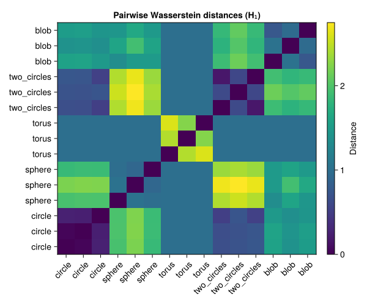

```julia
fig = Figure(size = (600, 500))
ax = Axis(
    fig[1, 1],
    title = "Pairwise Wasserstein distances (H₁)",
    xticks = (1:n_shapes, shape_names),
    yticks = (1:n_shapes, shape_names),
    xticklabelrotation = π / 4,
)
heatmap!(ax, dist_matrix)
Colorbar(fig[1, 2], limits = extrema(dist_matrix), label = "Distance")
fig
```

## 16.5 What the distances capture

Let’s think about what each shape’s persistence should look like:

| Shape | $\beta_0$ | $\beta_1$ | Expected signature |
| --- | --- | --- | --- |
| Circle | 1 | 1 | One persistent loop |
| Sphere | 1 | 0 | No persistent loops (but a nontrivial $H_2$ class) |
| Torus | 1 | 2 | Two persistent loops |
| Two circles | 2 → 1 | 2 | Two persistent loops (one per circle) |
| Blob | 1 | 0 | No persistent features |

Using only $H_1$, we expect:

- circles to stand apart because they have one strong loop;
- spheres and blobs to look similar, since both have trivial $H_1$;
- tori and two-circle clouds to look similar, since both have two prominent loops.

To distinguish sphere from blob, we would need to look at $H_2$ as well, since the sphere has a cavity while the blob does not.

## 16.6 Persistence images as features

A natural workflow for classification tasks is:

1. Compute persistence diagrams for each sample.
2. Convert diagrams to a fixed-size vector representation such as persistence images, persistence landscapes, or Betti curves.
3. Feed these vectors into a standard classifier.

Here we use persistence images, which convert persistence diagrams into fixed-size arrays:

```julia
function safe_persistence_image(diagram; kwargs...)
    if isempty(diagram)
        return zeros(5, 5)
    else
        pi = PersistenceImage([diagram]; kwargs...)
        return pi(diagram)
    end
end

images = [safe_persistence_image(d[2]) for d in diagrams]
```

[output not shown]

These matrices can then be flattened and fed to a standard machine-learning model. This lets us combine topological information with the usual classification toolbox without having to design custom classifiers from scratch.

## 16.7 Robustness to noise and sampling

One of the main strengths of persistent homology for shape comparison is its stability: small perturbations of the input point cloud should produce small perturbations of the persistence diagram, and therefore small changes in the distances.

Let’s verify that numerically:

```julia
noise_levels = [0.01, 0.05, 0.1, 0.2, 0.3]
base_circle = as_matrix(sphere(100, dim = 2))

circle_variants = [
    EuclideanSpace(base_circle .+ nl .* randn(MersenneTwister(i), 2, 100))
    for (i, nl) in enumerate(noise_levels)
]

diagrams_circle = [compute_ph(X) for X in circle_variants]

base_diagram = diagrams_circle[1][2]
for (d, nl) in zip(diagrams_circle, noise_levels)
    if !isempty(base_diagram) && !isempty(d[2])
        dist = Wasserstein()(base_diagram, d[2])
        println("Noise level $nl -> Wasserstein distance: $(round(dist, digits = 4))")
    end
end
```

```
Noise level 0.01 -> Wasserstein distance: 0.0
Noise level 0.05 -> Wasserstein distance: 0.1343
Noise level 0.1 -> Wasserstein distance: 0.2557
Noise level 0.2 -> Wasserstein distance: 0.873
Noise level 0.3 -> Wasserstein distance: 1.366
```

The distances should increase gradually as the noise grows, rather than jumping unpredictably. That is exactly the kind of robustness that makes persistent homology useful for comparing noisy geometric data.

## 16.8 Summary

In this chapter we learned:

- persistence diagrams can serve as topological fingerprints of shapes;
- Wasserstein distances turn those fingerprints into a metric on shapes;
- persistence images provide fixed-size features for machine learning;
- the whole procedure is stable under noise.

This same workflow applies to 3D scans, image contours, molecular structures, and many other kinds of geometric data.